# ForageModv02 Supplementary Analysis

## Population maintenance?

First, we checked to see whether all model runs maintained a population across all 3500 ticks.

```r
all.exp = unique(data$exp)

end.tick = unique(data$`tick-limit`)
fd = data %>% filter(ticks == end.tick)
finished.exp = unique(fd$exp)

finished.data = data %>% filter(exp %in% finished.exp)
unfinished.data = data %>% filter(!(exp %in% finished.exp))
length(unique(unfinished.data$exp))
```

```
## [1] 0
```

None of our modeled scenarios resulted in population extinction.

```r
data = data %>% filter(exp %in% finished.exp)
```

## Population during model run

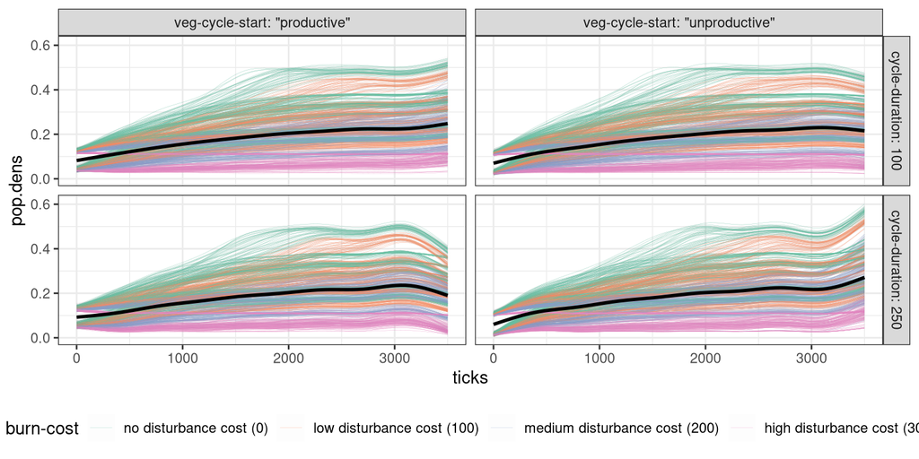

We looked at linear rates of changes within each climate period of the model to get a more detailed understanding of population change during model run.

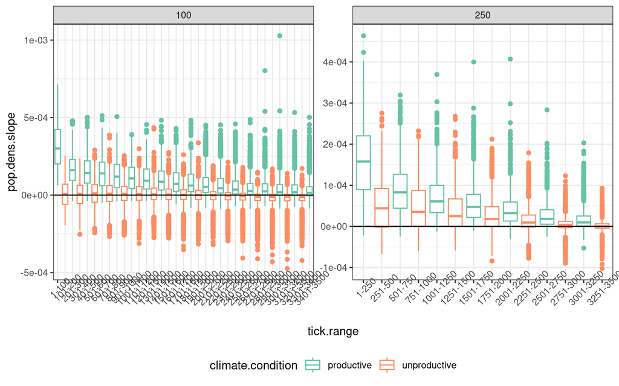

```r
ggplot(rates %>% filter(`veg-cycle-start` == "\"productive\"")) +
  geom_boxplot(aes(x = tick.range, y = pop.dens.slope, color = climate.condition)) +
  facet_wrap(~ `cycle-duration`, scales = "free") +
  geom_hline(aes(yintercept = 0), color = "black") +
  scale_color_brewer(palette = "Set2") +
  theme(legend.position = "bottom", axis.text.x = element_text(angle = 45))
```

We find that with short climate cycles, unproductive periods see essentially no change in population, with slopes being essentially zero. With longer climatic cycles, there is slight positive population change during unproductive periods at the beginning of model run.

Conversely, there is pretty consistent population growth during productive periods of the model until populations reach an equilibrium around 3000 ticks. The results show that population grows more quickly during productive periods at the beginning of model run, with rates of change decreasing toward zero by the end of the model. This demonstrates the effect of a carrying capacity in the model.

We can investigate this carrying capacity by looking at how many patches on the landscape are available to be foraged during a given time interval and how this is related to the change in population density over that same interval.

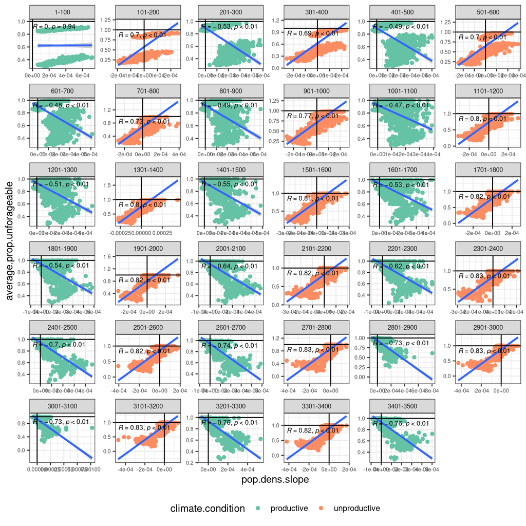

We can see that, with short environmental intervals, change in population density over a climatic interval is highly correlated with the proportion of patches that cannot be foraged, indicating that population is indeed controlled by access to energy.

Interestingly, we see opposite correlations for productive vs unproductive climatic windows. During productive periods, there will be population growth (positive slopes) with more forageable land (low proportions of unforageable patches). Conversely, during unproductive periods, there is more frequently population decline and this is strongly associated with lower proportions of unforageable land. This perhaps simply captures the fact that population decline allows for more land to be left unforaged, so smaller proportions of unforageable land, during a climatic interval. When more of the landscape is unforageable (higher proportions), we see a pattern of population stagnation in unproductive climatic intervals because there is not enough energy to allow for growth.

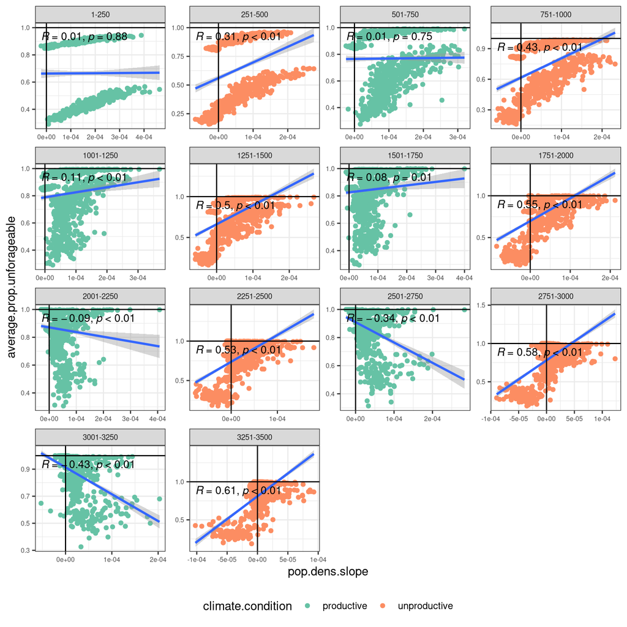

When climatic periods are longer, the significant and strong relationship between change in population density and proportions of unforageable patches is reduced or disappears in productive periods until the end of model run. This suggests that with longer climatic cycling, a different aspect of the environment is controlling population density initially.

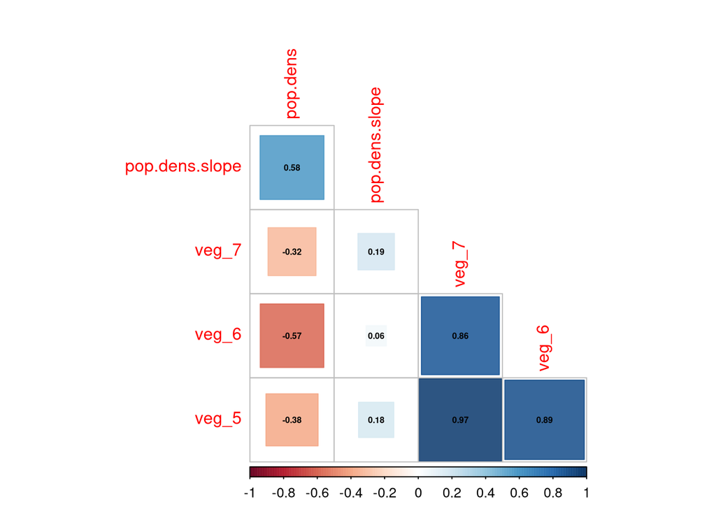

```r
outputs = c(
  "pop.dens", #pop count/world size
  "pop.dens.slope",
  #"burnt",
  "veg_7",
  "veg_6",
  "veg_5"
)

data.mid = data %>% dplyr::filter(`cycle-duration`== 250) %>%
  dplyr::filter(`veg-cycle-start` == "\"productive\"") %>%
  dplyr::filter(ticks > 1500 & ticks <= 1750) %>%
  group_by(exp) %>%
  summarize(pop.dens = mean(pop.dens),
            burnt = mean(burnt),
            veg_7 = mean(veg_7),
            veg_6 = mean(veg_6),
            veg_5 = mean(veg_5)) %>%
  left_join(rates %>%
              dplyr::filter(tick.range == "1501-1750") %>%
              dplyr::filter(`veg-cycle-start` == "\"productive\"") %>%
              dplyr::select(exp, pop.dens.slope),
            by = c("exp"))

pvalue.mid = psych::corr.test(data.mid %>% select_at(outputs))$p
corrplot::corrplot(cor(data.mid %>% select_at(outputs), use = "pairwise.complete.obs"),
                   method = "square", addCoef.col = "black",
                   col = scales::alpha(corrplot::COL2("RdBu"), alpha = 0.85),
                   p.mat = pvalue.mid, insig="blank", sig.level=0.1,
                   type = "lower", number.cex = 0.5, diag=F)
```

When we look at the correlations between the slope of change in population density for a middle productive period in model runs with longer climatic cycles, we see a significant positive correlation with proportions of high vegetation types (that is patches that produce more resources). This suggests that, even if most of the landscape cannot be foraged, access to a few high value patches is enough to allow for population growth. If forageable patches have lower resource values, then populations will not grow.

## Forager probability of burning patches

We examined the effects of all model parameters on burning probability across model run using linear regressions. We model the effect of the different parameter settings on model behavior. We also model change over model run by including “ticks” as a independent variable. Finally, we investigate the interaction between time and model parameters.

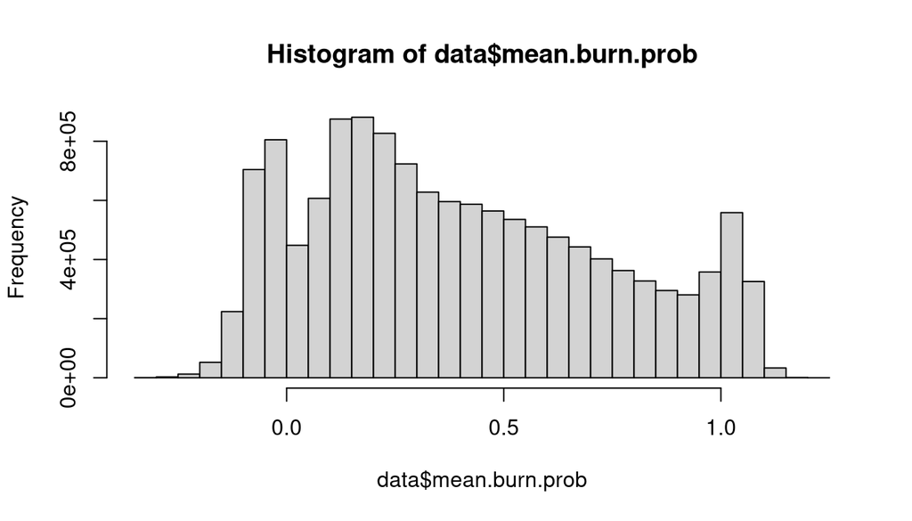

```r
hist(data$mean.burn.prob)
```

```r
mbp.fit1 = lm(mean.burn.prob ~ ticks + (.), data = data %>% dplyr::select_at(c("mean.burn.prob", "ticks", parameters)))
mbp.fit2 = lm(mean.burn.prob ~ ticks:(.), data = data %>% dplyr::select_at(c("mean.burn.prob", "ticks", parameters)))
mbp.fit3 = lm(mean.burn.prob ~ ticks*(.), data = data %>% dplyr::select_at(c("mean.burn.prob", "ticks", parameters)))

anova(mbp.fit1, mbp.fit2, mbp.fit3)
```

```
## Analysis of Variance Table
##
## Model 1: mean.burn.prob ~ ticks + (ticks + `cycle-duration` + `veg-cycle-start` +
##     `veg-distribution` + `burnt-neighbor-limit` + `burn-cost` +
##     `burn-veg-type-threshold` + `movement-model`)
## Model 2: mean.burn.prob ~ ticks:(ticks + `cycle-duration` + `veg-cycle-start` +
##     `veg-distribution` + `burnt-neighbor-limit` + `burn-cost` +
##     `burn-veg-type-threshold` + `movement-model`)
## Model 3: mean.burn.prob ~ ticks * (ticks + `cycle-duration` + `veg-cycle-start` +
##     `veg-distribution` + `burnt-neighbor-limit` + `burn-cost` +
##     `burn-veg-type-threshold` + `movement-model`)
##     Res.Df    RSS Df Sum of Sq      F    Pr(>F)
## 1 13443828 260844
## 2 13443828  93893  0    166951
## 3 13443818  86300 10      7593 118282 < 2.2e-16 ***
## ---
## Signif. codes:  0 '***' 0.001 '**' 0.01 '*' 0.05 '.' 0.1 ' ' 1
```

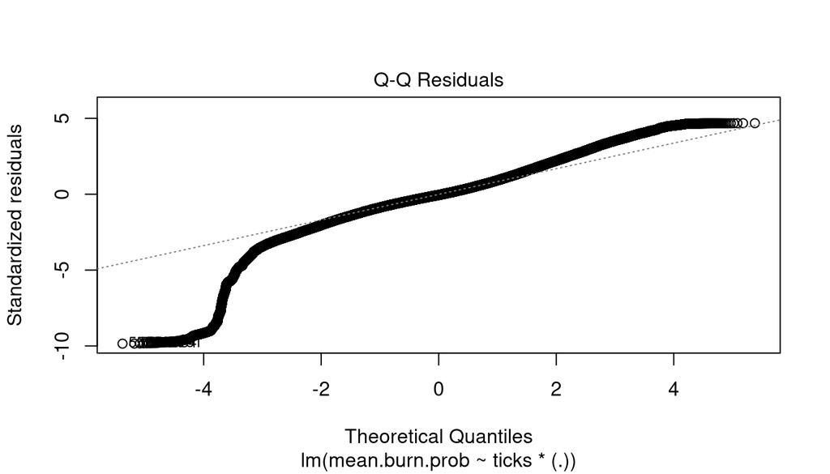

```r
plot(mbp.fit3, which = 2)
```

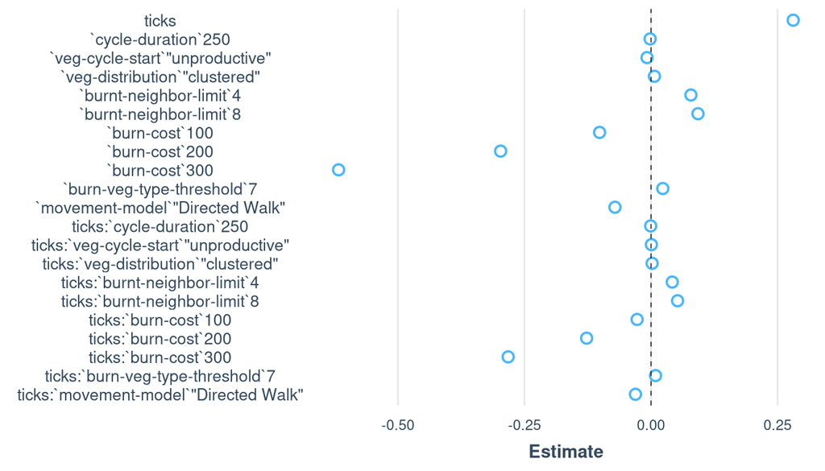

```r
plot_summs(mbp.fit3, scale = T)
```

Every parameter significantly affects burning probability on average across model run (independent variables) as well as how burning probability changes during model run (interaction variables). The scaled regression variables shown above also demonstrate that *burn-cost* has the strongest effect on the evolution of burning probability across model run.

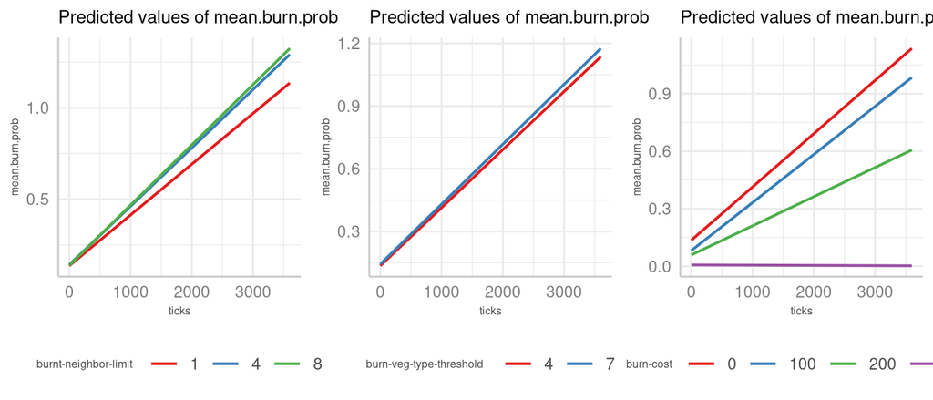

In general, parameters that add limits to burning behaviors (*burn-cost*, *burnt-neighbor-limit*, *burn-veg-type-threshold*) reduce the rate of increase of burning probabilities through model run. The increase of burning probabilities during model run is also faster when agents move randomly.

This model behavior is confirmed by looking at the effects of model parameters on slope of the linear relationship between ticks and burning probability.

```r
bp.rates = data.frame(
  exp = character(0),
  slope = numeric(0)
)
experiments = unique(data$exp)
for(x in experiments) {
  lmdata = data %>% filter(exp == x)
  fit = lm(mean.burn.prob ~ ticks, data = lmdata)
  bp.rates[nrow(bp.rates) + 1, ] <- c(x, summary(fit)$coefficients[2,1])
}
bp.rates = bp.rates %>% left_join(data %>% select_at(c("exp", parameters)), by = "exp", multiple = "first")
bp.rates$slope = as.numeric(bp.rates$slope)

bp.rates[,parameters] = lapply(bp.rates[,parameters], as.factor)
bp.rates$`veg-distribution` = factor(bp.rates$`veg-distribution`, levels = c("\"random\"", "\"clustered\""))
bp.rates$`movement-model` = factor(bp.rates$`movement-model`, levels = c("\"Random Walk\"", "\"Directed Walk\""))

length(unique((bp.rates %>% filter(slope < 0))$exp))/length(unique(bp.rates$exp))
```

```
## [1] 0.121875
```

```r
neg.bprate = bp.rates %>% filter(slope < 0) %>% select_at(c(parameters)) %>% distinct()
table(neg.bprate$`burn-cost`)
```

```
##
##   0 100 200 300
##   0   0   0  61
```

Approximately 12% of all model runs result in a decreasing rate of change in burning probabilities. These occur when burning costs are 300, greater than the benefit gained from burning.

```r
rate.fit1= lm(slope ~ ., data = bp.rates %>% select_at(c("slope", parameters)))
rate.fit2 = lm(slope ~ .:., data = bp.rates %>% select_at(c("slope", parameters)))
anova(rate.fit1, rate.fit2)
```

```
## Analysis of Variance Table
##
## Model 1: slope ~ `cycle-duration` + `veg-cycle-start` + `veg-distribution` +
##     `burnt-neighbor-limit` + `burn-cost` + `burn-veg-type-threshold` +
##     `movement-model`
## Model 2: slope ~ (`cycle-duration` + `veg-cycle-start` + `veg-distribution` +
##     `burnt-neighbor-limit` + `burn-cost` + `burn-veg-type-threshold` +
##     `movement-model`):(`cycle-duration` + `veg-cycle-start` +
##     `veg-distribution` + `burnt-neighbor-limit` + `burn-cost` +
##     `burn-veg-type-threshold` + `movement-model`)
##   Res.Df        RSS Df  Sum of Sq      F    Pr(>F)
## 1   3829 3.6327e-06
## 2   3788 1.6139e-06 41 2.0188e-06 115.57 < 2.2e-16 ***
## ---
## Signif. codes:  0 '***' 0.001 '**' 0.01 '*' 0.05 '.' 0.1 ' ' 1
```

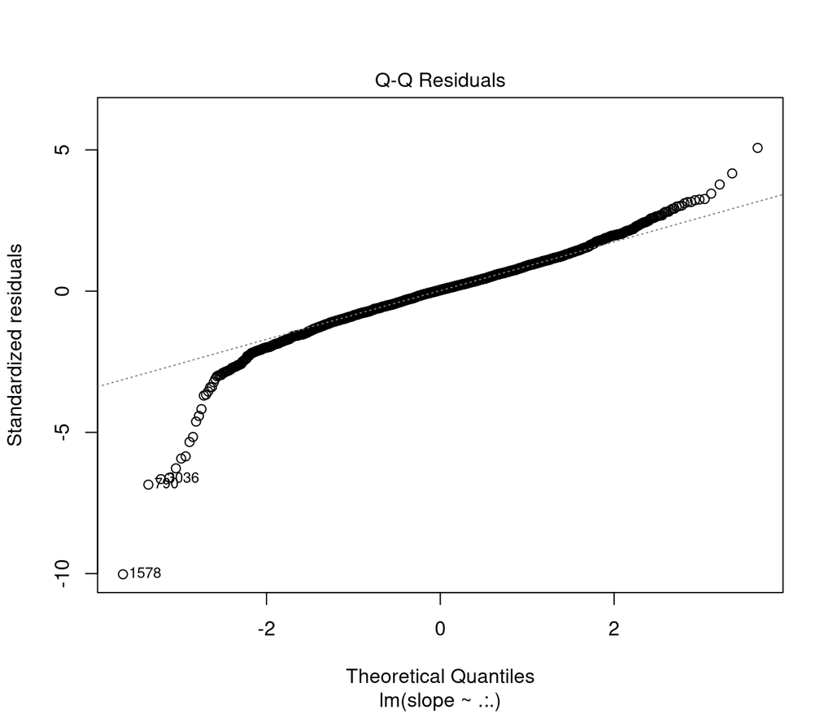

```r
plot(rate.fit2, which = 2)
```

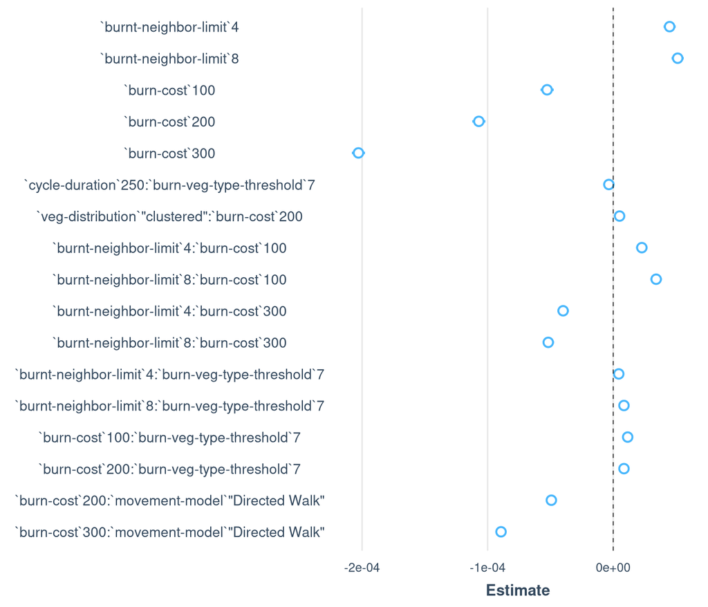

```r
rate.fit.df = rate.fit2 %>% broom::tidy() %>%
  mutate(p.signif = ifelse(p.value < 0.05, TRUE, FALSE)) %>%
  filter(p.signif == F)

plot_summs(rate.fit2, scale = T, omit.coefs = c("(Intercept)", rate.fit.df$term))
```

Positive selection for burning behaviors across most of the model runs occurs because there is a consistent low benefit to self of these behaviors. Here, we measure benefit to self as the number of times an agent forages from a patch where they were the last agent to burn it as a proportion of the average total number of foraging events at each tick.

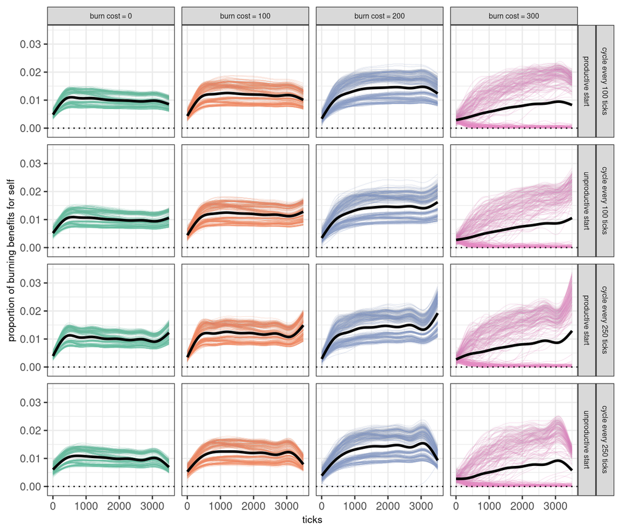

```r
ggplot(data %>% filter(ticks > 0)) +
  geom_smooth(aes(x = ticks, y = bself.prop, group = exp, color = as.factor(`burn-cost`)), alpha = 0.01, linewidth = 0.05) +
  geom_smooth(aes(x = ticks, y = bself.prop), se = F, color = "black") +
  scale_color_brewer(palette = "Set2",
                     labels = c("no burn cost (0)", "low burn cost (100)", "high burn cost (200)", "highest burn cost (300)")) +
  geom_hline(yintercept = 0, linetype = "dotted") +
  facet_grid(`cycle-duration` + `veg-cycle-start` ~ `burn-cost`, labeller =
                labeller(`burn-cost` = bc.labs, `cycle-duration` = cycle.labs, `veg-cycle-start` = start.labs)) +
  labs(y = "proportion of burning benefits for self", x = "ticks", color = "cost of burning") +
  theme(legend.position = "none", axis.title = element_text(size = 8), strip.text = element_text(size = 6))
```

Benefit to self consistently occurs at low levels across model run for most parameter settings, resulting in the evolution of increased burning behaviors.

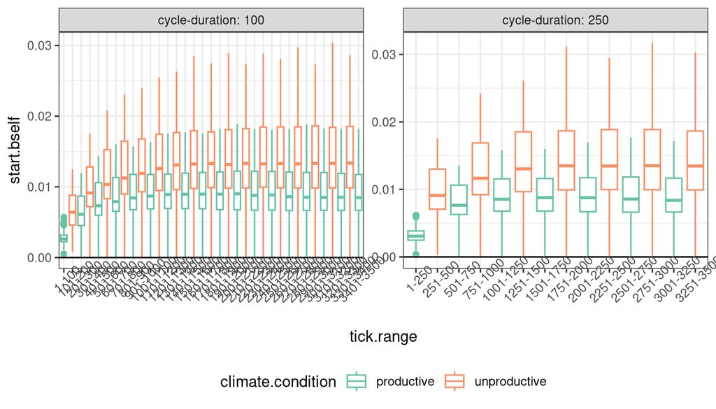

Across model run, we see higher proportions of self benefit during foraging during unproductive periods, in part due to reduced population density in these climatic intervals.

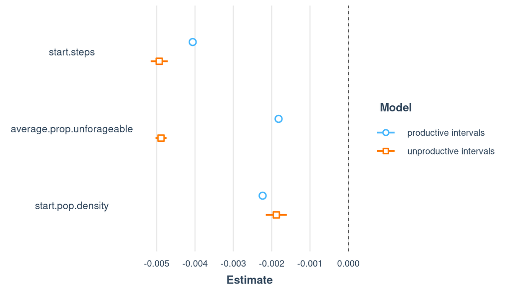

```r
fit1 = lmer(end.bself ~ start.steps + average.prop.unforageable + start.pop.density +  (1 | tick.range),
            data = rates %>% filter(`veg-cycle-start` == "\"productive\"") %>% filter(`cycle-duration` == "100") %>% filter(climate.condition == "productive"))
fit2 = lmer(end.bself ~ start.steps + average.prop.unforageable + start.pop.density + start.steps + (1 | tick.range),
            data = rates %>% filter(`veg-cycle-start` == "\"productive\"") %>% filter(`cycle-duration` == "100") %>% filter(climate.condition == "unproductive"))

plot_summs(fit1, fit2, scale = T, model.names = c("productive intervals", "unproductive intervals"))
```

This self benefit is significantly affected by forager mobility, population density, and proportion of unforageable land, as these will impact the number of patches agents have access to for foraging.

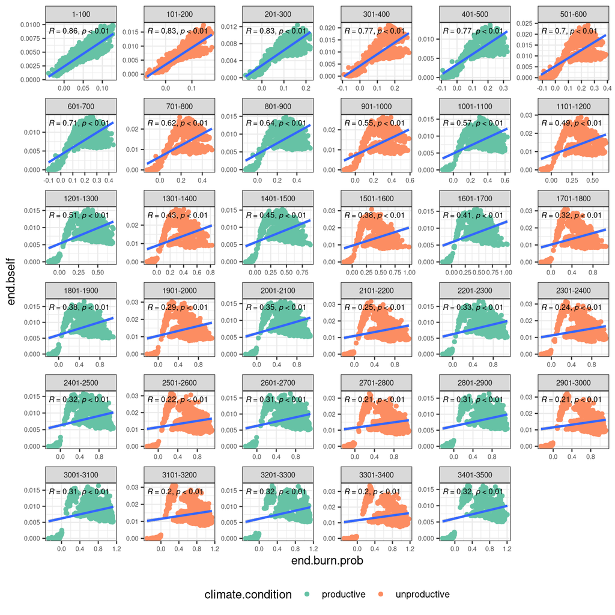

```r
ggplot(rates %>% filter(`veg-cycle-start` == "\"productive\"") %>% filter(`cycle-duration` == "100")) +
  geom_point(aes(x = end.burn.prob, y = end.bself, color = climate.condition)) +
  geom_smooth(aes(x = end.burn.prob, y = end.bself), method = "lm") +
  stat_cor(mapping = aes(x = end.burn.prob, y = end.bself),
           method = "pearson", p.accuracy = 0.01, r.accuracy = 0.01, size = 2.5) +
  facet_wrap(~ tick.range, scales = "free") +
  scale_color_brewer(palette = "Set2") +
  theme(legend.position = "bottom") +
  theme(axis.text = element_text(size = 6), legend.position = "bottom",
        strip.text = element_text(size = 7))
```

When looking at how self benefit relates to burning probabilities within climatic intervals, these outputs are fairly strongly correlated at the beginning of model run. We can also see that, within each climatic interval, low burning probabilities cluster very tightly with low proportions of self benefit. This supports the claim that benefit to self drives positive selection for this behavior.

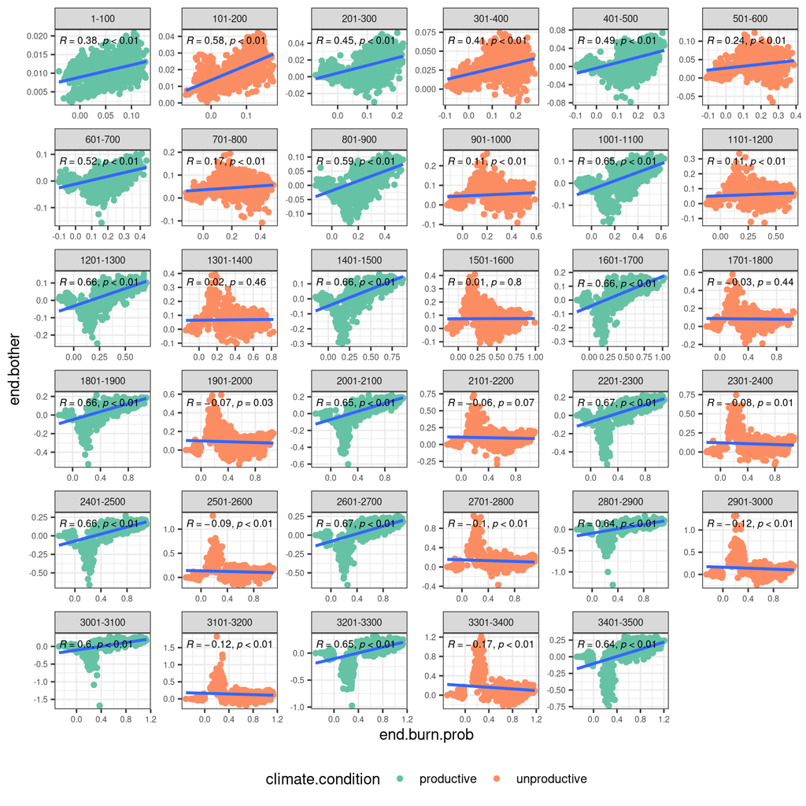

```r
ggplot(rates %>% filter(`veg-cycle-start` == "\"productive\"") %>% filter(`cycle-duration` == "100")) +
  geom_point(aes(x = end.burn.prob, y = end.bother, color = climate.condition)) +
  geom_smooth(aes(x = end.burn.prob, y = end.bother), method = "lm") +
  stat_cor(mapping = aes(x = end.burn.prob, y = end.bother),
           method = "pearson", p.accuracy = 0.01, r.accuracy = 0.01, size = 2.5) +
  facet_wrap(~ tick.range, scales = "free") +
  scale_color_brewer(palette = "Set2")  +
  theme(legend.position = "bottom") +
  theme(axis.text = element_text(size = 6), legend.position = "bottom",
        strip.text = element_text(size = 7))
```

By the end of model run, burning probabilities are more highly positively correlated with benefit to others, meaning that the highest probabilities of burning behaviors occur when agents besides the one that burned a patch are benefiting from the increased resource productivity. This suggests that there is a the collective benefit of burning allows for further positive selection of this behavior.

### Positive evolution of burning behaviors with high burning costs

One interesting model result is the evolution of high probabilities of burning under conditions where this behavior has a high cost - that is a cost that outweighs the energetic benefits gained.

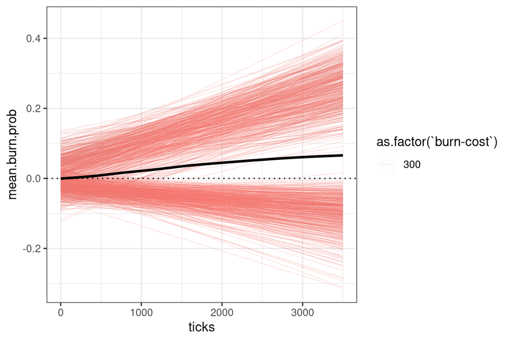

```
## [1] 0.4875
```

Around 49% of these high cost scenarios result in decreasing probabilities of burning behaviors.

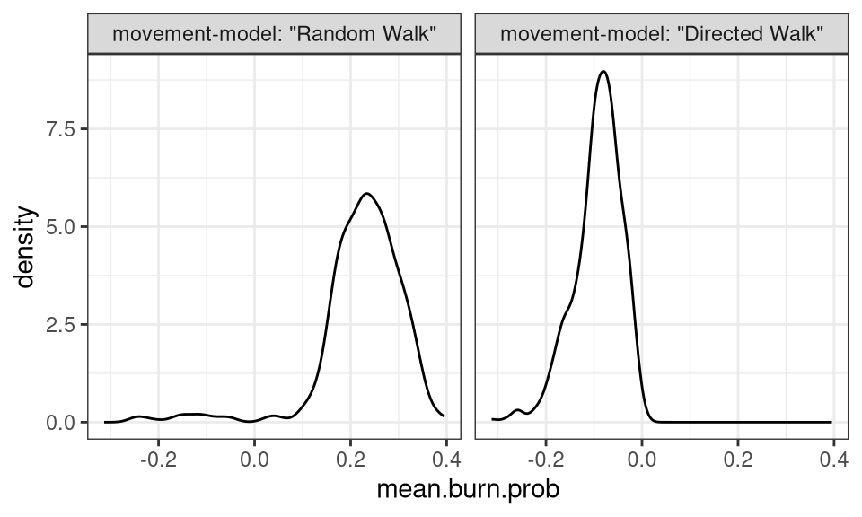

```r
#hist((high.burn %>% filter(ticks == 3500))$mean.burn.prob)

ggplot(high.burn %>% filter(ticks == 3500)) +
  geom_density(aes(x = mean.burn.prob)) +
  facet_wrap(~ `movement-model`, labeller = label_both)
```

This bimodal distribution in final burning probability appears to be primarily related to the movement model that agents employ. Under random walks, agents are more likely to develop increased burning probabilities. Under directed walks, the high cost of burning keeps burning probabilities low or even negative. This is likely because the targeting of high yield patches allows agents to access enough energy without needing to engage in high cost behaviors. When agents have to rely on randomly encountering high value patches, it is more useful to put energy into creating an environment with more high value patches through burning behaviors.

## Burnt landscape proportions

Initial correlations reveal that the proportion of burnt landscape is significantly highly correlated with population density and the average burning probability of agents.

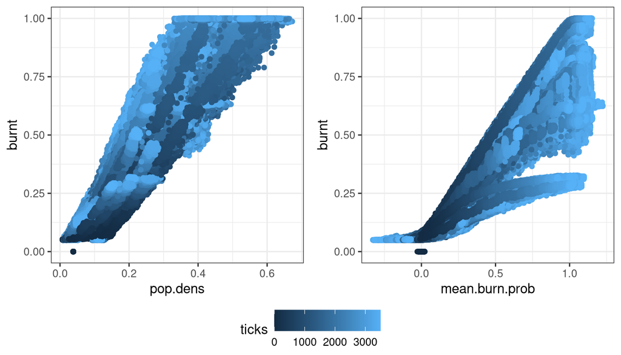

We used regressions on the proportions of burnt landscape to look at the effects of each parameter. We compared Beta regression and logistic regressions, which are often used for modeling proportion data, and linear regressions using AIC.

```r
beta.data = data %>% mutate(burnt = ifelse(burnt == 0, burnt + 0.00001, burnt)) %>% mutate(burnt = ifelse(burnt == 1, burnt - 0.00001, burnt))

beta.fit1 = betareg(burnt ~ ticks*(ticks + `cycle-duration` +
                                     `veg-cycle-start` + `veg-distribution` + `burn-cost` + `burn-veg-type-threshold` +  `burnt-neighbor-limit` +
                                     `movement-model`), data = beta.data %>% select_at(c("ticks", "burnt", parameters)))

log.fit1 = glm(burnt ~ ticks*(ticks + `cycle-duration` +
                                `veg-cycle-start` + `veg-distribution` + `burn-cost` + `burn-veg-type-threshold` +  `burnt-neighbor-limit` +
                                `movement-model`), data = data %>% select_at(c("ticks", "burnt", parameters)), family = binomial)

lin.fit1 = lm(burnt ~ ticks*(ticks + `cycle-duration` +
                               `veg-cycle-start` + `veg-distribution` + `burn-cost` + `burn-veg-type-threshold` +  `burnt-neighbor-limit` +
                               `movement-model`), data = data %>% select_at(c("ticks", "burnt", parameters)))

AIC(beta.fit1)
```

```
## [1] -30663594
```

```r
AIC(log.fit1)
```

```
## [1] 7754388
```

```r
AIC(lin.fit1)
```

```
## [1] -26381640
```

```r
AIC(beta.fit1) < AIC(lin.fit1)
```

```
## [1] TRUE
```

Comparison of AIC shows that the Beta regression performs best.

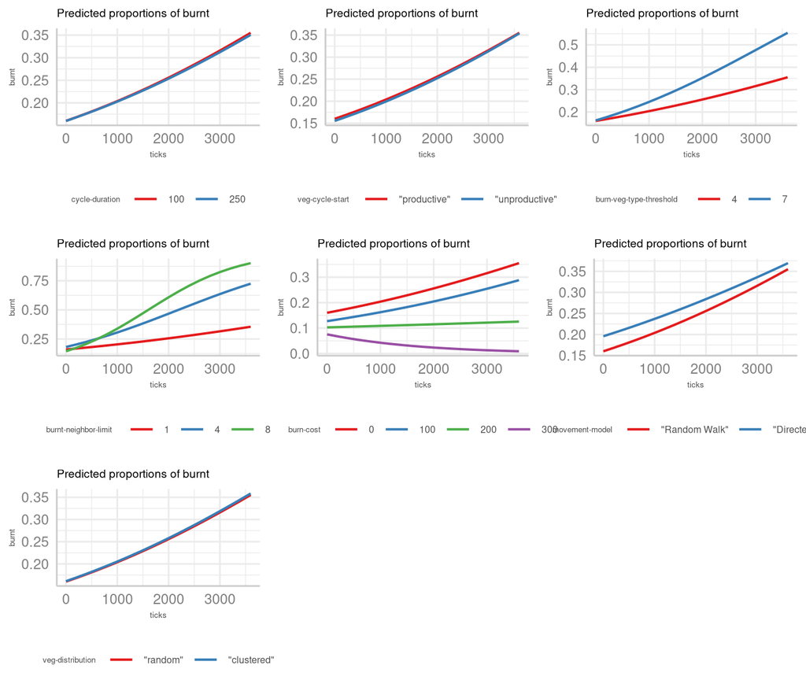

The predicted proportions of burnt landscape from the best fit Beta regression model show that increasing limits on location of burning or increasing cost to burning significantly affect the amount of burnt landscape. This matches the results above for the effect of these parameters on mean burning probability. This is also consistent with the high positive correlation between proportion of burnt landscape and burning probability through time.

## Spatial clustering of vegetation types

Spatial clustering (and its converse spatial heterogeneity) of vegetation types is assessed via Moran’s I values. We limit our analysis to those significant values of Moran’s I to assess the degree of clustering (positive values) or dispersion (negative values). We assessed the effects of the different parameters using linear regressions.

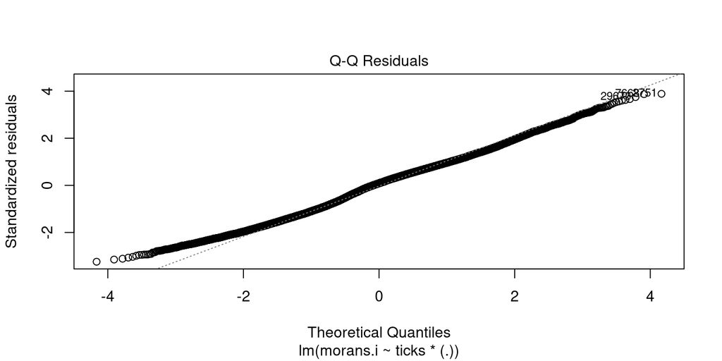

```r
veg.100.prod = readRDS("../results/outputs/veg_moransi_100-prod.rds")
veg.100.unprod = readRDS("../results/outputs/veg_moransi_100-unprod.rds")
veg.250.prod = readRDS("../results/outputs/veg_moransi_250-prod.rds")
veg.250.unprod = readRDS("../results/outputs/veg_moransi_250-unprod.rds")

veg.100.prod = veg.100.prod %>% filter(exp %in% finished.exp)
veg.100.unprod = veg.100.unprod %>% filter(exp %in% finished.exp)
veg.250.prod = veg.250.prod %>% filter(exp %in% finished.exp)
veg.250.unprod = veg.250.unprod %>% filter(exp %in% finished.exp)

veg.100.prod = veg.100.prod %>% filter(ticks != 1000) %>% filter(ticks != 2000)
veg.100.unprod = veg.100.unprod %>% filter(ticks != 1000) %>% filter(ticks != 2000)
veg.250.prod = veg.250.prod %>% filter(ticks != 1000) %>% filter(ticks != 2000)
veg.250.unprod = veg.250.unprod %>% filter(ticks != 1000) %>% filter(ticks != 2000)

parameters = c(
  "cycle_duration",  # 100, 250
  "veg_cycle_start", # productive, unproductive
  "veg_distribution", # random, clustered
  "burnt_neighbor_limit", # 1, 4, 8
  "burn_cost", # 0, 50
  "burn_veg_type_threshold", # 4, 7
  "movement_model" #Random, Directed
)

reg.params = parameters[c(3:7)]
veg.100.prod[,reg.params] = lapply(veg.100.prod[,reg.params], as.factor)
veg.100.unprod[,reg.params] = lapply(veg.100.unprod[,reg.params] , as.factor)
veg.250.prod[,reg.params] = lapply(veg.250.prod[,reg.params], as.factor)
veg.250.unprod[,reg.params] = lapply(veg.250.unprod[,reg.params] , as.factor)

veg.100.prod$veg_distribution = factor(veg.100.prod$veg_distribution, levels = c("\"random\"", "\"clustered\""))
veg.100.unprod$veg_distribution = factor(veg.100.unprod$veg_distribution, levels = c("\"random\"", "\"clustered\""))
veg.250.prod$veg_distribution = factor(veg.250.prod$veg_distribution, levels = c("\"random\"", "\"clustered\""))
veg.250.unprod$veg_distribution = factor(veg.250.unprod$veg_distribution, levels = c("\"random\"", "\"clustered\""))

veg.100.prod$movement_model = factor(veg.100.prod$movement_model, levels = c("\"Random Walk\"", "\"Directed Walk\""))
veg.100.unprod$movement_model = factor(veg.100.unprod$movement_model, levels = c("\"Random Walk\"", "\"Directed Walk\""))
veg.250.prod$movement_model = factor(veg.250.prod$movement_model, levels = c("\"Random Walk\"", "\"Directed Walk\""))
veg.250.unprod$movement_model = factor(veg.250.unprod$movement_model, levels = c("\"Random Walk\"", "\"Directed Walk\""))

# hist(veg.100.prod$morans.i)
# hist(veg.100.unprod$morans.i)
# hist(veg.250.prod$morans.i)
# hist(veg.250.unprod$morans.i)

veg.100.prod.fit1 = lm(morans.i ~ ticks*(.), data = veg.100.prod %>% filter(signif == T) %>% select_at(c("ticks", "morans.i", reg.params)))

veg.100.unprod.fit1 = lm(morans.i ~ ticks*(.), data = veg.100.unprod %>% filter(signif == T) %>% select_at(c("ticks", "morans.i", reg.params)))

veg.250.prod.fit1 = lm(morans.i ~ ticks*(.), data = veg.250.prod %>% filter(signif == T) %>% select_at(c("ticks", "morans.i", reg.params)))

veg.250.unprod.fit1 = lm(morans.i ~ ticks*(.), data = veg.250.unprod %>% filter(signif == T) %>% select_at(c("ticks", "morans.i", reg.params)))

plot(veg.100.prod.fit1, which = 2)
```

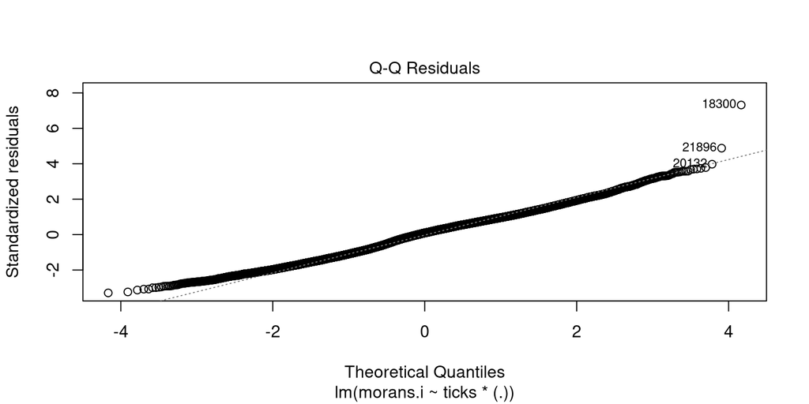

```r
plot(veg.100.unprod.fit1, which = 2)
```

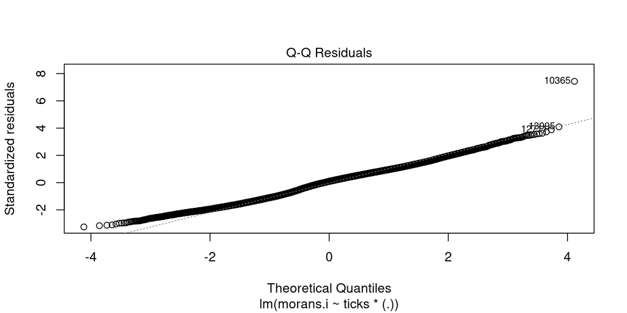

```r
plot(veg.250.prod.fit1, which = 2)
```

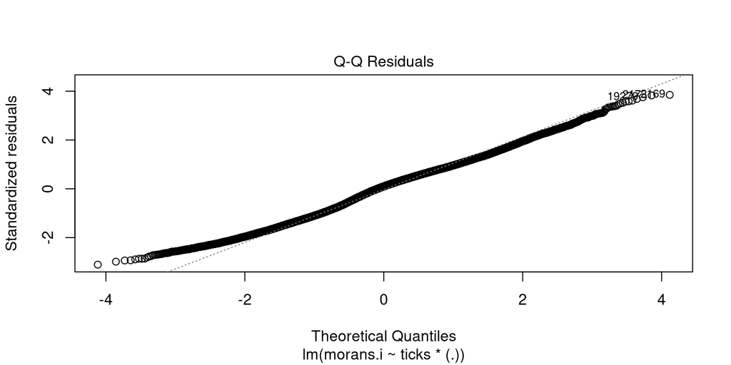

```r
plot(veg.250.unprod.fit1, which = 2)
```

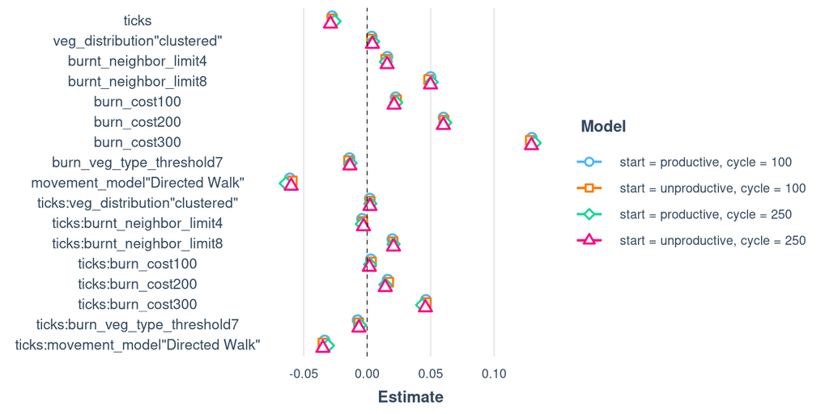

```r
plot_summs(veg.100.prod.fit1, veg.100.unprod.fit1,veg.250.prod.fit1, veg.250.unprod.fit1, model.names = c(
  "start = productive, cycle = 100",
  "start = unproductive, cycle = 100",
  "start = productive, cycle = 250",
  "start = unproductive, cycle = 250"
), scale = T)
```

Looking at the standardized regression coefficients, we can see that high/medium cost of burning behaviors and a directed walk movement model have the greatest impact on clustering of vegetation types. Interestingly, the underlying distribution of maximum potential vegetation types for patches has essentially no impact on spatial clustering of vegetation types relative to the other parameters.

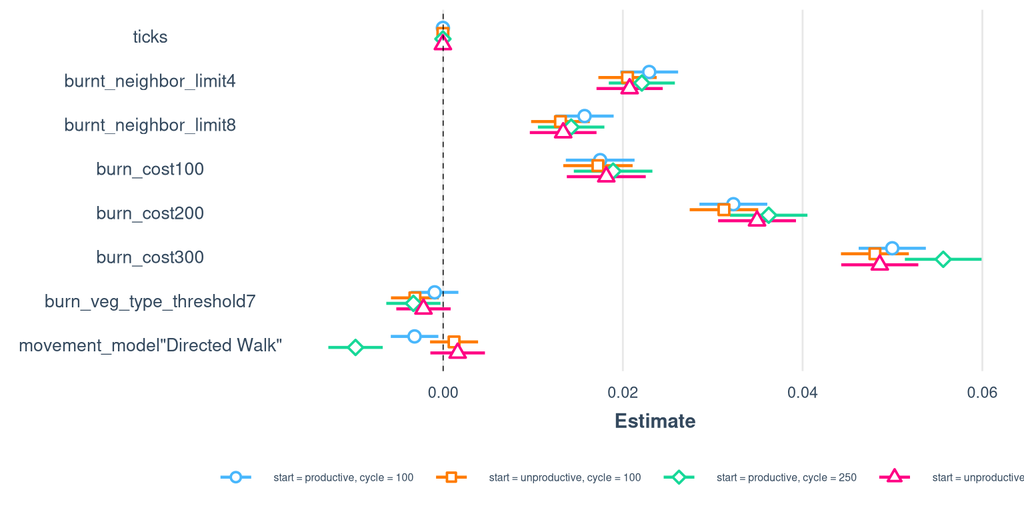

```r
plot_summs(veg.100.prod.fit1, veg.100.unprod.fit1,veg.250.prod.fit1, veg.250.unprod.fit1, model.names = c(
  "start = productive, cycle = 100",
  "start = unproductive, cycle = 100",
  "start = productive, cycle = 250",
  "start = unproductive, cycle = 250"
), coefs = c("ticks", "natural_ignition0.05", "veg_distribution\"random\"", "burnt_neighbor_limit4", "burnt_neighbor_limit8", "burn_cost100", "burn_cost200", "burn_cost300", "burn_veg_type_threshold7", "movement_model\"Directed Walk\"")) +
  theme(legend.position = "bottom", legend.title = element_blank(), legend.text = element_text(size = 6))
```

Comparing across individual models for the experiments split by whether the model starts in a productive or unproductive state and split by the model climatic cycle duration, we can see that most of the parameters have similar effects. The parameter with significant differences in regression coefficients between the models is: *movement-model* . We can see that when model run starts in a productive state and the climatic cycles are longer, Directed Walks allow for, on average, less spatial clustering of vegetation types.

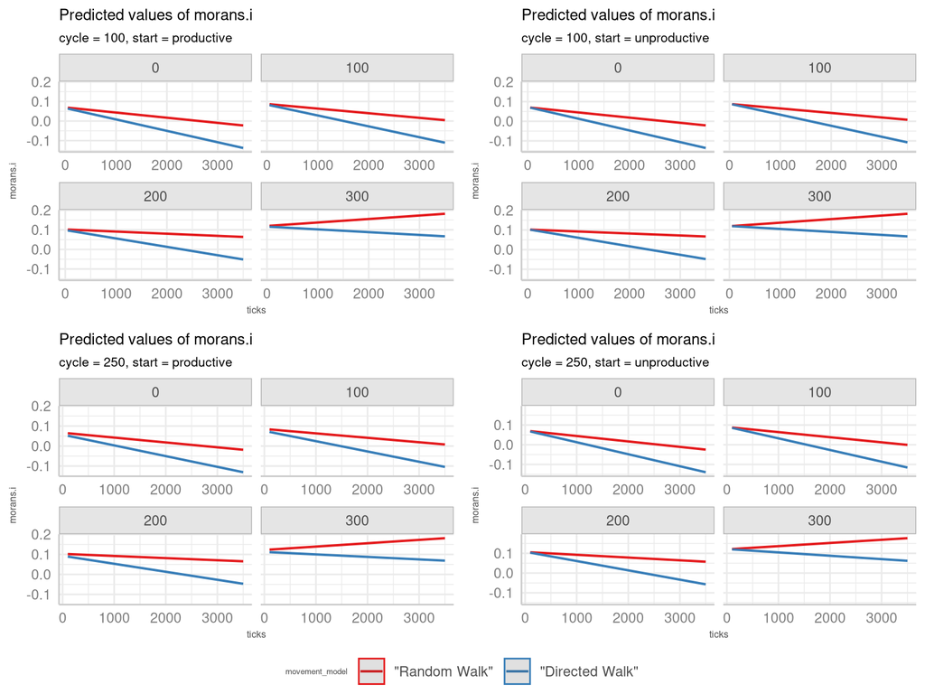

```r
ggarrange(
  ggeffects::ggpredict(veg.100.prod.fit1, terms = c("ticks", "movement_model", "burn_cost")) %>%
    plot(show_data = FALSE, show_ci = TRUE) +
    theme(legend.title = element_text(size = 5), title = element_text(size = 8), axis.title = element_text(size = 6)) +
    labs(subtitle = "cycle = 100, start = productive"),
  ggeffects::ggpredict(veg.100.unprod.fit1, terms = c("ticks", "movement_model", "burn_cost")) %>%
    plot(show_data = FALSE, show_ci = TRUE) +
    theme(legend.title = element_text(size = 6), title = element_text(size = 8), axis.title = element_text(size = 6)) +
    labs(subtitle = "cycle = 100, start = unproductive"),
  ggeffects::ggpredict(veg.250.prod.fit1, terms = c("ticks", "movement_model", "burn_cost")) %>%
    plot(show_data = FALSE, show_ci = TRUE) +
    theme(legend.title = element_text(size = 6), title = element_text(size = 8), axis.title = element_text(size = 6)) +
    labs(subtitle = "cycle = 250, start = productive"),
  ggeffects::ggpredict(veg.250.unprod.fit1, terms = c("ticks", "movement_model", "burn_cost")) %>%
    plot(show_data = FALSE, show_ci = TRUE) +
    theme(legend.title = element_text(size = 6), title = element_text(size = 8), axis.title = element_text(size = 6)) +
    labs(subtitle = "cycle = 250, start = unproductive"),
  common.legend = T, legend = "bottom", nrow = 2, ncol = 2)
```

When we look at how vegetation clustering changes over time with different burning costs (facets) and different movement models, it is clear that directed walks result in a faster rate of decline in spatial clustering than random walks across all burning costs. When burning costs are low/none, this decrease is even steeper as more burning occurs, with spatial autocorrelation becoming more dispersed, at negative values, by the end of model run. This is consistent with above results that directed walk result in faster rates of increase in burning probabilities and more burnt patches over time.

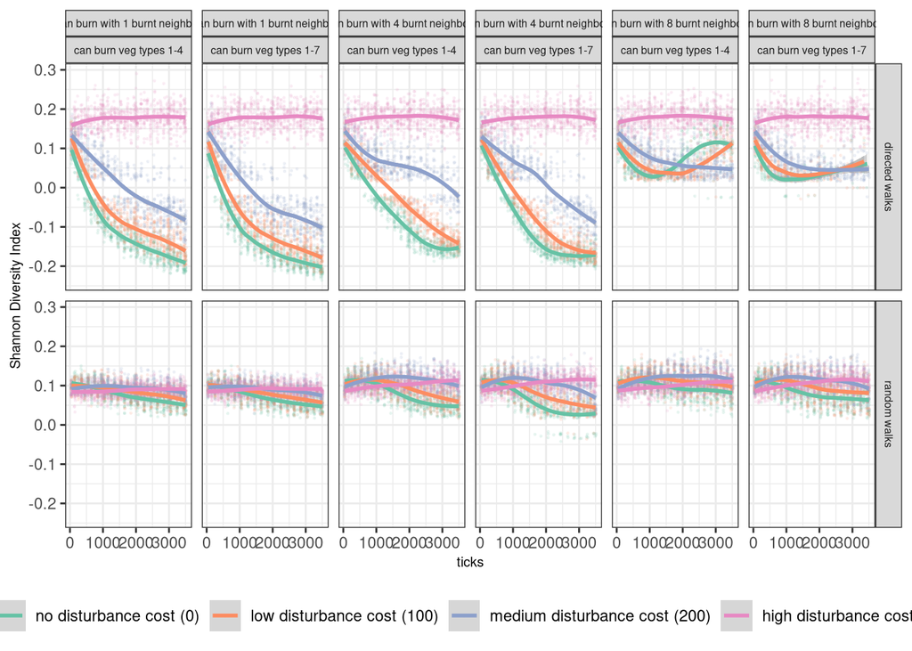

```r
plot.data = veg.data %>% filter(signif == T) %>% filter(cycle_duration == 100) %>% filter(veg_cycle_start == "\"productive\"")
plot.data$burn_cost = as.factor(plot.data$burn_cost)

 ggplot(plot.data) +
  geom_jitter(data = plot.data %>% filter(burn_cost == 0), mapping =
                aes(x = ticks, y = morans.i, group = ticks, color = burn_cost), alpha = 0.1, size = 0.25) +
  geom_jitter(data = plot.data %>% filter(burn_cost == 100), mapping =
                aes(x = ticks, y = morans.i, group = ticks, color = burn_cost), alpha = 0.1, size = 0.25) +
  geom_jitter(data = plot.data %>% filter(burn_cost == 200), mapping =
                aes(x = ticks, y = morans.i, group = ticks, color = burn_cost), alpha = 0.1, size = 0.25) +
  geom_jitter(data = plot.data %>% filter(burn_cost == 300), mapping =
                aes(x = ticks, y = morans.i, group = ticks, color = burn_cost), alpha = 0.1, size = 0.25) +
  geom_smooth(mapping = aes(x = ticks, y = morans.i, color = burn_cost)) +
  facet_grid(movement_model ~ burnt_neighbor_limit + burn_veg_type_threshold, labeller =
               labeller(burnt_neighbor_limit = bn.labs,
                        burn_veg_type_threshold = bt.labs,
                        movement_model = move.labs)) +
  labs(color = "", y = "Shannon Diversity Index") +
  scale_color_brewer(palette = "Set2",
                     labels = c("no disturbance cost (0)", "low disturbance cost (100)", "medium disturbance cost (200)", "high disturbance cost (300)", "productive interval", "unproductive interval")) +
  theme(legend.position = "bottom",
        strip.text = element_text(size = 6),
        axis.title = element_text(size = 7.5))
```

There are also differing trends based on spatial limits and vegetation limits on burning behaviors. When patches can only be burnt with 4 or less burnt neighbors, spatial clustering of vegetation types is much more decreased, particularly for lower disturbance costs that allow for more burning.

## Vegetation diversity

Vegetation diversity was measured by Shannon’s Diversity Index. This metric considers the proportional abundances of vegetation types to indicate whether one type dominates or abundances are more evenly spread across all types. A SDI value of 0 indicates a lack of diversity with abundance being concentrated in a single species. Higher SDI values indicate more diversity of vegetation types.

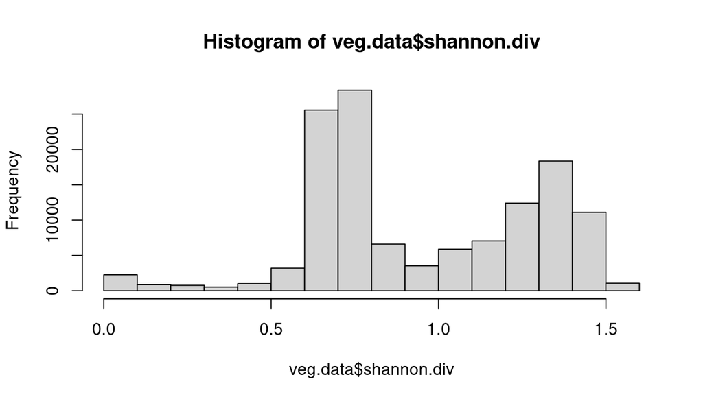

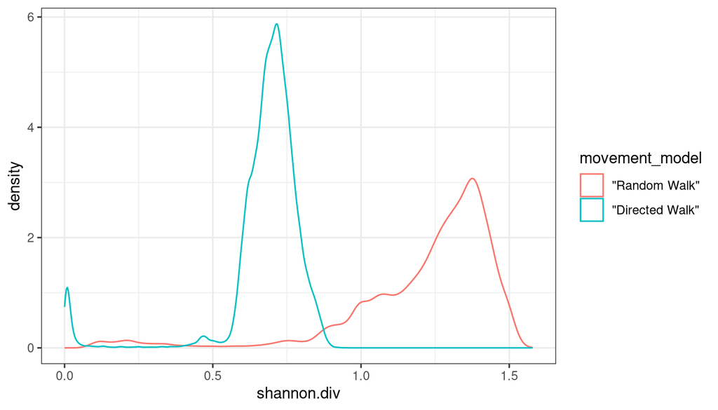

The distribution of this metric is bimodal across model runs. This bimodality is caused by the different movement models used: directed walks result in less diversity than random walks.

We fit a GAM to vegetation type diversity for model runs with random walks because it is a better fit than a linear model. We use GAM to investigate how the effects of the parameters change through time.

```r
veg.data.r = veg.data %>% filter(movement_model == "\"Random Walk\"")
reg.params = parameters = c(
  "cycle_duration",  # 100, 250
  "veg_cycle_start", # productive, unproductive
  "veg_distribution", # random, clustered
  "burnt_neighbor_limit", # 1, 4, 8
  "burn_cost", # 0, 50
  "burn_veg_type_threshold"
)
veg.data.r[,reg.params] = lapply(veg.data.r [,reg.params], as.factor)

rw.gam1 = gam(shannon.div ~
                #s(ticks, by = natural_ignition) +
                s(ticks, by = veg_cycle_start) +
                s(ticks, by = veg_distribution) +
                s(ticks, by = burn_cost)  +
                s(ticks, by = burn_veg_type_threshold) +
                s(ticks, by = burnt_neighbor_limit) +
                s(ticks, by = cycle_duration), data = veg.data.r)

rw.gam2 = gam(shannon.div ~ veg_cycle_start + veg_distribution + burn_cost + burn_veg_type_threshold + burnt_neighbor_limit + cycle_duration +
                #s(ticks, by = natural_ignition) +
                s(ticks, by = veg_cycle_start) +
                s(ticks, by = veg_distribution) +
                s(ticks, by = burn_cost)  +
                s(ticks, by = burn_veg_type_threshold) +
                s(ticks, by = burnt_neighbor_limit) +
                s(ticks, by = cycle_duration), data = veg.data.r)

anova(rw.gam1, rw.gam2, test = "Chisq")
```

```
## Analysis of Deviance Table
##
## Model 1: shannon.div ~ s(ticks, by = veg_cycle_start) + s(ticks, by = veg_distribution) +
##     s(ticks, by = burn_cost) + s(ticks, by = burn_veg_type_threshold) +
##     s(ticks, by = burnt_neighbor_limit) + s(ticks, by = cycle_duration)
## Model 2: shannon.div ~ veg_cycle_start + veg_distribution + burn_cost +
##     burn_veg_type_threshold + burnt_neighbor_limit + cycle_duration +
##     s(ticks, by = veg_cycle_start) + s(ticks, by = veg_distribution) +
##     s(ticks, by = burn_cost) + s(ticks, by = burn_veg_type_threshold) +
##     s(ticks, by = burnt_neighbor_limit) + s(ticks, by = cycle_duration)
##   Resid. Df Resid. Dev     Df Deviance  Pr(>Chi)
## 1     64261     2746.9
## 2     64247     1598.0 13.392   1148.9 < 2.2e-16 ***
## ---
## Signif. codes:  0 '***' 0.001 '**' 0.01 '*' 0.05 '.' 0.1 ' ' 1
```

```r
rw.fit1 = lm(shannon.div ~ ticks*(.), data = veg.data.r %>% select_at(c("ticks", "shannon.div", reg.params)))

AIC(rw.gam2)
```

```
## [1] -55002.36
```

```r
AIC(rw.fit1)
```

```
## [1] -48005.73
```

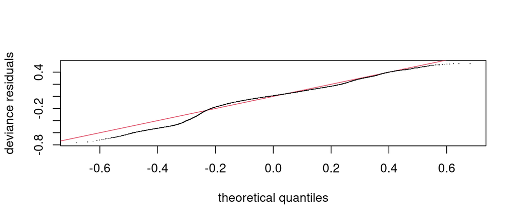

```r
qq.gam(rw.gam2)
```